# Comparación de Clasificadores

Master en Big Data

José Tomás Palma Méndez

1 de marzo de 2023

# 1 Introducción

En esta sesión prácaticas vamos analizar cómo realizar comparaciones entre predictores en diferentes situaciones.

**Paquetes necesarios:** `nortest`, `coin`, `car`, `ez` y `PMCMRplus`.

Los conjuntos de datos utilizados se pueden descargar del aula virtual.

# 2 Dos clasificadores en un dominio

## 2.1 Caso paramétrico

Para un determinado conjunto de datos se han probado dos clasificadores: **C50** y **redes neuronales**. Cada clasificares se han evaluado utilizando una validación cruzada con 10 pliegues. En el fichero `ejemplo1.dat` puedes encontrar el índice `Kappa` para cada uno de los 10 pliegues . Con estos datos ¿qué podemos decir sobre la eficacia de dichos clasificadores?.

```r
ejemplo1 <- read.csv("Datasets/ejemplo1.dat")
datatable(ejemplo1)
```

|  | nnet | C50 |
| --- | --- | --- |
| 1 | 0.814814814814815 | 0.666666666666667 |
| 2 | 0.58974358974359 | 0.764705882352941 |
| 3 | 0.6 | 0.818181818181818 |
| 4 | 0.179487179487179 | 0.294117647058824 |
| 5 | 0.814814814814815 | 1 |
| 6 | 0 | -0.111111111111111 |
| 7 | 0 | 0.333333333333333 |
| 8 | 0.764705882352941 | 0.764705882352941 |
| 9 | 0.818181818181818 | 0.818181818181818 |
| 10 | 0 | -0.111111111111111 |

Como podemos observar estamos comparando dos clasificadores en un dominio, por lo tanto, primero deberíamos comprobar si se cumplen las condiciones para realizar un *test T de Student con medidas pareadas*: normalidad y homogeneidad de las varianzas (homocedasticidad). Para comprobar la normalidad podemos utilizar dos test: el *test de Shapiro-Wilk* y el *test de Kolmogorov-Smirnov con la corrección Lilliefors*. El *test de Shapiro-Wilk* se recomienda cuando el número de muestras es menor a 50, mientras que el *test de Kolmogorov-Smirnov* con la corrección *Lilliefors* se recomienda cuando las muestras son mayores a 50. En este caso, aunque sólo tenemos 10 muestras vamos a realizar ambos test para aclarar cómo se aplican. Recordad que la normalidad hay que comprobarla sobre las diferencias entre las medidas obtenidas en cada pliegue, ya que lo que queremos comprobar es si existen diferencias significativas entre las medias del rendimiento entre las dos clasificadores. En nuestro caso el test intenta comprobar estas hipótesis:

$$H_0: X \sim
\mathcal{N}(\mu,\,\sigma^{2})$$
$$H_1: X \not\sim \mathcal{N}(\mu,\,\sigma^{2})$$

```r
test.shapiro <- shapiro.test(ejemplo1$nnet-ejemplo1$C50)
test.shapiro
```

```
##
##  Shapiro-Wilk normality test
##
## data:  ejemplo1$nnet - ejemplo1$C50
## W = 0.93528, p-value = 0.5018
```

```r
library(nortest)
test.lillie <- lillie.test(ejemplo1$nnet-ejemplo1$C50)
test.lillie
```

```
##
##  Lilliefors (Kolmogorov-Smirnov) normality test
##
## data:  ejemplo1$nnet - ejemplo1$C50
## D = 0.1602, p-value = 0.6613
```

Como podemos ver, no podemos rechazar la hipótesis nula de que la muestra procede de una distribución normal, con un 95% de confianza (*W=* 0.935 , *p-value*= 0.502 y *D*= 0.16, *p-value*= 0.661). En este caso sólo nos habría hecho falta aplicar el test de Shapiro-Wilk al ser la muestra menor que 50.

Una vez comprobada la normalidad, hay que proceder con la comprobación de la homocedasticidad (homogeneidad de las varianzas). Para ello tenemos dos test: el *test de Levene* y el *test de Bartlett*. Este último es más potente en el caso de que se pueda asumir la normalidad, como es nuestro caso.

```r
datos <- stack(list(nnet=ejemplo1$nnet,C50=ejemplo1$C50))
library(car)
test.levene <- leveneTest(values ~ ind, data = datos)
test.levene
```

```
## Levene's Test for Homogeneity of Variance (center = median)
##       Df F value Pr(>F)
## group  1  0.0017 0.9672
##       18
```

```r
test.barlett <- bartlett.test(values ~ ind, data = datos)
test.barlett
```

```
##
##  Bartlett test of homogeneity of variances
##
## data:  values by ind
## Bartlett's K-squared = 0.05302, df = 1, p-value = 0.8179
```

Como podemos ver, los dos test confirman al 95% que no podemos rechazar la hipótesis de que las varianzas en las medidas obtenidas en cada clasificador son homogéneas (*F*= 0.002, *p-value*= 0.967 > 0.05) y *K*<sup>2</sup>= 0.053, *p-value*= 0.818 > 0.05).

Al cumplirse las condiciones de aplicabilidad del *test T de Student con medidas pareadas*, podemos comprobar si las diferencias detectadas en los clasificadores es significativa o no. Es decir, las hipótesis que intenta comprobar el test se pueden expresar de la siguiente manera:

$$H_0:
\mu_{C50}-\mu_{nnet} = 0$$
$$H_1:
\mu_{C50}-\mu_{nnet} \neq 0$$

```r
t.test <- t.test(ejemplo1$nnet,ejemplo1$C50, paired = TRUE)
t.test
```

```
##
##  Paired t-test
##
## data:  ejemplo1$nnet and ejemplo1$C50
## t = -1.2692, df = 9, p-value = 0.2362
## alternative hypothesis: true difference in means is not equal to 0
## 95 percent confidence interval:
##  -0.18250096  0.05131642
## sample estimates:
## mean of the differences
##             -0.06559227
```

Atendiendo a los resultados del test, podemos concluir que con el 95% de confianza las diferencias entre las medias obtenidas por cada clasificador no son significativas (no podemos rechazar la hipótesis de que la diferencias entre las medias sea 0). Es decir, no existen diferencias significativas entre los dos clasificadores con el conjunto de datos utilizado (|*T*|= 1.269 < *T*<sub>9,0.975</sub>, *p-value* = 0.236). Hay que tener en cuenta que hubiera dado el mismo resultado si utilizamos un test t de Student para una muestra, que es lo que se hace el paquete `caret` con la función `compare_models()`. En este caso la hipótesis nula consiste en que la media de la población es 0. Para ello, hay que llamar a la función `t.test()` con la diferencia obtenida en cada pliegue:

```r
t.test2 <- t.test(ejemplo1$nnet-ejemplo1$C50)
t.test2
```

```
##
##  One Sample t-test
##
## data:  ejemplo1$nnet - ejemplo1$C50
## t = -1.2692, df = 9, p-value = 0.2362
## alternative hypothesis: true mean is not equal to 0
## 95 percent confidence interval:
##  -0.18250096  0.05131642
## sample estimates:
##   mean of x
## -0.06559227
```

## 2.2 Caso no paramétrico

Supongamos ahora que queremos comprobar como se comportan un clasificador **SVM** y un **análisis lineal discriminante** sobre determinado conjunto de datos. Una vez entrenados los clasificadores se han evaluado mediante una validación cruzada con 10 pliegues. En el fichero `ejemplo2.dat` se pueden encontrar los valores para la precisión para cada uno de los pliegues.

```r
ejemplo2 <- read.csv("Datasets/ejemplo2.dat")
datatable(ejemplo2)
```

|  | SVM | LDA |
| --- | --- | --- |
| 1 | 0.933333333333333 | 0.933333333333333 |
| 2 | 0.875 | 0.875 |
| 3 | 0.8125 | 0.875 |
| 4 | 0.8125 | 0.875 |
| 5 | 0.933333333333333 | 0.933333333333333 |
| 6 | 0.8 | 0.8 |
| 7 | 0.6 | 0.533333333333333 |
| 8 | 0.9375 | 0.9375 |
| 9 | 0.75 | 0.9375 |
| 10 | 0.8 | 0.733333333333333 |

Ahora volvemos a comprobar las condiciones de aplicabilidad del *test t de Student con medidas pareadas*. Primero comprobamos la normalidad de la muestra:

```r
test.shapiro <- shapiro.test(ejemplo2$SVM-ejemplo2$LDA)
test.shapiro
```

```
##
##  Shapiro-Wilk normality test
##
## data:  ejemplo2$SVM - ejemplo2$LDA
## W = 0.83634, p-value = 0.03989
```

Empecemos por el *test de McNemar*, que necesita como datos la matriz de confusión para los dos métodos considerados:

```r
matriz.conf <- read.csv("Datasets/matrizConfEjemplo2.dat", header = TRUE, row.names = 1)
datatable(matriz.conf)
```

|  | FALLECE | VIVE |
| --- | --- | --- |
| FALLECE | 31 | 11 |
| VIVE | 17 | 136 |

Recordemos que el *test de McNemar* comprueba si las proporciones de error son iguales, es decir

$$H_0: p_{FP} = p_{FN}$$

$$H_1: p_{FP} \neq p_{FN}$$

```r
test.macnemar <- mcnemar.test(as.matrix(matriz.conf))
test.macnemar
```

```
##
##  McNemar's Chi-squared test with continuity correction
##
## data:  as.matrix(matriz.conf)
## McNemar's chi-squared = 0.89286, df = 1, p-value = 0.3447
```

En este caso podemos afirmar con el 95% de confianza que las proporciones de error no muestran diferencias significativas ($\chi$<sup>2</sup>= 0.893, *p-value*= 0.345). Es decir, no se aprecian diferencias significativas entre los modelos.

El *test de Wilcoxon* comparará las medianes de las dos muestras en vez de las medias. Es decir, las hipótesis que se quieren comprobar se pueden expresar de la siguiente manera:

$$H_0: \eta_{svm} =
\eta_{lda}$$

$$H_1: \eta_{svm} \neq
\eta_{lda}$$

```r
test.wilcox <- wilcox.test(ejemplo2$SVM,ejemplo2$LDA, paired = TRUE)
test.wilcox
```

```
##
##  Wilcoxon signed rank test with continuity correction
##
## data:  ejemplo2$SVM and ejemplo2$LDA
## V = 7, p-value = 1
## alternative hypothesis: true location shift is not equal to 0
```

```r
library(coin)
datos <- stack(list(svm=ejemplo2$SVM,lda = ejemplo2$LDA))
test.wilcox.exact <- wilcox_test(values ~ ind, data = datos, paired = TRUE)
test.wilcox.exact
```

```
##
##  Asymptotic Wilcoxon-Mann-Whitney Test
##
## data:  values by ind (svm, lda)
## Z = -0.64966, p-value = 0.5159
## alternative hypothesis: true mu is not equal to 0
```

Analizando los resultados, podemos afirmar que no podemos rechazar la hipótesis nula de que las medianas de las muestras sean iguales con un 95% de confianza *Z=* -0.65, *p-vaue*= 0.516). Es decir, la diferencia entre los dos modelos no son estadísticamente significativas.

# 3 Dos predictores en múltiples dominios

Para comparar dos predictores se han utilizado 10 conjuntos de datos. Concretamente, se ha calculado la precisión de una **máquina de soporte de vectores (SVM)** con kernel lineal y **un árbol C50** en cada uno de los 10 conjuntos de datos. En la siguiente tabla se puede ver el resultado en cada uno de los conjunto de datos.

```r
ejemplo3 <- read.csv("Datasets/Ejemplo3.dat")
datatable(ejemplo3)
```

|  | X | SVMLinear | C50 |
| --- | --- | --- | --- |
| 1 | hepatitis | 0.844166666666667 | 0.862916666666667 |
| 2 | iris | 0.96 | 0.946666666666667 |
| 3 | cox2 | 0.805041628122109 | 0.835291396854764 |
| 4 | oil | 0.969166666666667 | 0.95979797979798 |
| 5 | dhfr | 0.926136363636364 | 0.910700757575758 |
| 6 | German | 0.747 | 0.756 |
| 7 | Seg | 0.803320033495887 | 0.845928771981676 |
| 8 | Breast | 0.964243723208818 | 0.961406701076021 |
| 9 | Pima | 0.773444976076555 | 0.757860560492139 |
| 10 | Sonar | 0.745606060606061 | 0.832077922077922 |

En este caso estamos comparando dos clasificadores en múltiples dominios y, como hemos comentado en clase de teoría, la recomendación es utilizar el *test de la suma de rangos de Wilcoxon para muestras pareadas* (o su versión de una muestra, calculando la diferencia de la precisión obtenida en cada dataset).

```r
test.wilcox <- wilcox.test(ejemplo3$SVMLinear,ejemplo3$C50, paired = TRUE)
test.wilcox
```

```
##
##  Wilcoxon signed rank exact test
##
## data:  ejemplo3$SVMLinear and ejemplo3$C50
## V = 19, p-value = 0.4316
## alternative hypothesis: true location shift is not equal to 0
```

Como podemos ver, podemos afirmar que, con una confianza del 95%, no existen diferencias significativas entre la precisión de los dos clasificadores sobre el conjunto de datos seleccionados (*V* = 19 > $V_{10}^{0.05}$, *p-value*= 0.432 > 0.05).

# 4 Múltiples predictores en múltiples dominios

## 4.1 Caso paramétrico

Para esta sección vamos a seguir uno de los ejemplos presentados en [1]. En este ejemplo dispones de los datos de precisión de tres clasificadores en 10 conjunto de datos diferentes. El objetivo es determinar si existen diferencias significativas entre los distintos clasificadores en dichos conjunto de datos. Los resultados de entretar los 3 clasificadores sobre los 10 conjuntos se pueden ver en la siguiente tabla:

```r
ejemplo4 <- read.csv("Datasets/Ejemplo4.csv", row.names = 1)
datatable(ejemplo4)
```

|  | classA | classB | classC |
| --- | --- | --- | --- |
| 1 | 0.8583 | 0.7586 | 0.8419 |
| 2 | 0.8591 | 0.7318 | 0.859 |
| 3 | 0.8612 | 0.6908 | 0.8383 |
| 4 | 0.8582 | 0.7405 | 0.8511 |
| 5 | 0.8628 | 0.7471 | 0.8638 |
| 6 | 0.8642 | 0.659 | 0.812 |
| 7 | 0.8591 | 0.7625 | 0.8638 |
| 8 | 0.861 | 0.751 | 0.8675 |
| 9 | 0.8595 | 0.705 | 0.8803 |
| 10 | 0.8612 | 0.7395 | 0.8718 |

En este caso, al comparar múltiples clasificadores en múltiples dominios, debemos aplicar el *test ANOVA de una vía para medidas pareadas* o su equivalente no paramétrico el *test de Friedman*. Para ello debemos de comprobar las condiciones de aplicabilidad para el *test ANOVA de una vía para medidas pareadas*: normalidad y esfericidad (el equivalente a la homocedasticidad para el ANOVA de medidas pareadas).

En el caso del *test ANOVA de una vía para medidas pareadas* se comprueba si las medias entre los diferentes clasificadores son iguales, es decir:

$$H_0: \mu_1 = \mu_2 = \ldots =
\mu_n$$

$$H_1: \text{ las medias no son iguales}$$

Seguidamente vamos a transformar la tabla para que nos sea más cómodo trabajar con algunas de las funciones que vamos a utilizar. La idea es generar una tabla en que tenga tres columnas: una para la precisión, otra para los clasificadores y otra para los conjuntos de datos.

```r
df4.stack <- stack(ejemplo4)
df4.stack$DataSet <- as.factor(rep(row.names(ejemplo4), times = 3))
names(df4.stack) <- c("Accuracy","Method", "DataSet")
datatable(df4.stack)
```

|  | Accuracy | Method | DataSet |
| --- | --- | --- | --- |
| 1 | 0.8583 | classA | 1 |
| 2 | 0.8591 | classA | 2 |
| 3 | 0.8612 | classA | 3 |
| 4 | 0.8582 | classA | 4 |
| 5 | 0.8628 | classA | 5 |
| 6 | 0.8642 | classA | 6 |
| 7 | 0.8591 | classA | 7 |
| 8 | 0.861 | classA | 8 |
| 9 | 0.8595 | classA | 9 |
| 10 | 0.8612 | classA | 10 |

[output cut: 20 more lines]

Para la condición de normalidad, debemos comprobar que la muestra de cada uno de los grupos procede de una población con distribución normal. Como hemos comentado anteriormente, esto se puede realizar mediante el *test de Shapiro-Wilks*:

```r
test.shapiro <- tapply(df4.stack$Accuracy, df4.stack$Method,shapiro.test)
test.shapiro
```

```
## $classA
##
##  Shapiro-Wilk normality test
##
## data:  X[[i]]
## W = 0.91888, p-value = 0.3477
##
##
## $classB
##
##  Shapiro-Wilk normality test
##
## data:  X[[i]]
## W = 0.87406, p-value = 0.1114
##
##
## $classC
##
##  Shapiro-Wilk normality test
##
## data:  X[[i]]
## W = 0.92585, p-value = 0.4083
```

Como se puede deducir de los datos, las precisiones obtenidas por cada clasificador en cada uno de los conjuntos de datos proceden de una distribución normal con un 95% de confianza (*W*<sub>ClassA</sub>= 0.919, *p-value*<sub>ClassA</sub>= 0.348, *W*<sub>ClassB</sub>= 0.874, *p-value*<sub>ClassB</sub> = 0.111, *W*<sub>ClassC</sub>= 0.926, *p-value*<sub>ClassC</sub>=0.408). El siguiente paso es comprobar la homogeneidad de las varianzas, que en el caso de un *ANOVA con medidas repetidas* se traduce en comprobar la esfericidad de la matriz de covarianzas. Este se puede hacer a través de la función `MauchlySphericityTest()` de la librería `superb`. En dicho test, la hipótesis nula es que la matriz de covarianzas cumple la propiedad de esfericidad.

```r
library(superb)
Mauchly.pvalue <- MauchlySphericityTest(ejemplo4)
sprintf("Mauchly test pvalue = %g", Mauchly.pvalue)
```

```
## [1] "Mauchly test pvalue = 0.212565"
```

Como podemos ver, con el 95% de confianza, no podemos rechazar la hipótesis nula de que la matriz de covarianzas cumple la propiedad de esfericidad.

También podríamos haber utilizado la función `ezANOVA()` del paquete `ez`, que nos calcula tanto el *test ANOVA para medidas repetidas* suponiendo que se cumple la esfericidad, el *test de Mauchly* y *test ANOVA para medidas repetidas* con la corrección de *p-value* para compensar el incumplimiento de la condición de esfericidad, utilizando el *Greenhouse-Geisser and Huynh-Feldt epsilon value*. En la función `ezANOVA()` debemos indicar en el parámetro `dv` la variable dependiente, en el parámetro `wid` la identificación de las muestras, en nuestro caso las bases de datos y en el parámetro `within` la variable predictora, en nuestro caso la que define los diferentes modelos que se están comparando.

```r
library(ez)
anova <- ezANOVA(data=df4.stack,dv=Accuracy, wid=DataSet, within = Method)
anova
```

```
## $ANOVA
##   Effect DFn DFd       F            p p<.05       ges
## 2 Method   2  18 142.418 9.259424e-12     * 0.8911672
##
## $`Mauchly's Test for Sphericity`
##   Effect         W         p p<.05
## 2 Method 0.6790051 0.2125652
##
## $`Sphericity Corrections`
##   Effect       GGe        p[GG] p[GG]<.05       HFe        p[HF] p[HF]<.05
## 2 Method 0.7570052 2.290742e-09         * 0.8776464 1.480308e-10         *
```

Como se puede apreciar, en primer lugar se nos muestra el resultado del *test ANOVA para medidas repetidas* suponiendo que se cumple la esfericidad, que nos indica que existen diferencias entre los clasificadores altamente significativas (*F*= 142.418, *p-value* < 10<sup>-4</sup>). El segundo resultado se corresponde con el *test de Mauchly* para la esfericidad, que nos indica que no podemos rechazar la hipótesis de que la matriz de covarianzas cumpla esta propiedad (*p-value*= 0.213). Los otros resultados que se muestran son el resultado de aplicar un procedimiento que permite corregir la desviación producida por cumplir con la esfericidad a los resultados de test ANOVA anteriormente realizados.

Como ya hemos indicado, ahora debemos proceder con el *test de Tukey* para identificar donde están las diferencias. Para ello vamos a utilizar la función `tukeyTest()` del paquete `PMCMRplus`.

```r
library(PMCMRplus)
tukey.test <- tukeyTest(Accuracy ~ Method, data=df4.stack)
summary(tukey.test)
```

```
##
##  Pairwise comparisons using Tukey's test
```

```
## data: Accuracy by Method
```

```
## alternative hypothesis: two.sided
```

```
## P value adjustment method: single-step
```

```
## H0
```

```
##                      q value   Pr(>|q|)
## classB - classA == 0 -18.587 9.0816e-13 ***
## classC - classA == 0  -0.777     0.8478
## classC - classB == 0  17.810 2.4455e-12 ***
```

```
## Signif. codes: 0 '***' 0.001 '**' 0.01 '*' 0.05 '.' 0.1 ' ' 1
```

Como se pueden ver en los resultados, existen diferencias altamente significativas entre el clasificador B y el clasificador A (*Z*= -18.587, *p-value* < 10<sup>-4</sup>) y el entre el B y el C (*Z*= 17.81, *p-value* < 10<sup>-4</sup>). En ambos casos, los datos estimados para la media de las diferencias indican que, teniendo en cuenta la precisión, el B es peor que el resto de los clasificadores. No podemos establecer diferencias significativas entre el A y el C (*Z*= -0.777, *p-value*= 0.848). Estos resultados también pueden ser analizados de forma gráfica a través de la función `plot()`

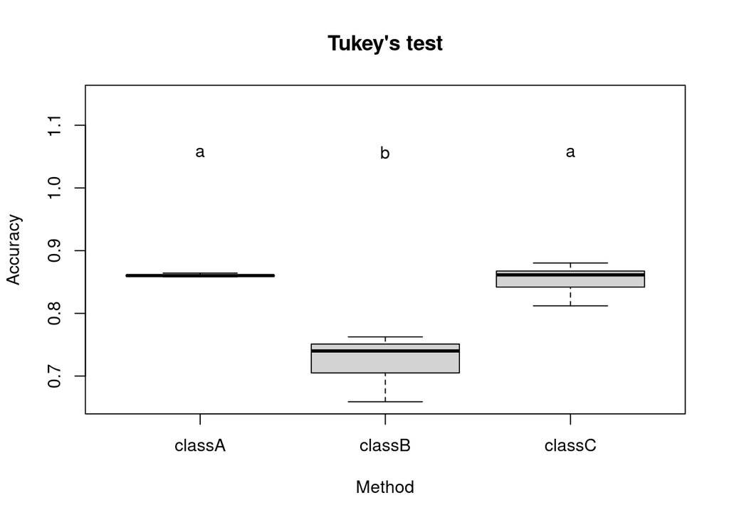

```r
plot(tukey.test)
```

En este gráfico, las letras sobre cada gráfico de cajas indica la pertenencia del modelo a un grupo. Los modelos para los que no se encuentran diferencias significativas están dentro del mismo grupo.

## 4.2 Caso no paramétrico

Supongamos que queremos comprobar la eficacia de una *SVM con kernel lineal*, un árbol *C5.0* y una *red neuronal* en diferentes conjuntos de datos. Para ello, hemos entrenado cada uno de los clasificadores en cada uno de los conjuntos de datos obteniendo el índice Kappa en cada evaluación. Los resultados se pueden apreciar en la siguiente tabla

```r
ejemplo5 <- read.csv("Datasets/Ejemplo3TablaKappa.csv", row.names = 1)
datatable(ejemplo5)
```

|  | SVMLinear | C50 | NNET |
| --- | --- | --- | --- |
| hepatitis | 0.458174809939516 | 0.523767082590612 | 0.441097551685787 |
| iris | 0.94 | 0.92 | 0.95 |
| cox2 | 0.35683940709102 | 0.392445958658784 | 0.427784822592468 |
| oil | 0.957298892167233 | 0.946610872814442 | 0.982978723404255 |
| dhfr | 0.842189926902351 | 0.809820436442751 | 0.843981686203457 |
| German | 0.357969830250058 | 0.378608229746804 | 0.388412620489012 |
| Seg | 0.567465969430804 | 0.664388004750073 | 0.578169825764421 |
| Breast | 0.92024803708331 | 0.914643646261184 | 0.931243421649512 |
| Pima | 0.476973939963955 | 0.457350946202137 | 0.485749422985114 |
| Sonar | 0.489954549038235 | 0.661161552893888 | 0.698527891015898 |

Como en el caso anterior, tenemos que elegir entre un *test ANOVA de una vía para medidas pareadas* o su equivalente no paramétrico el *test de Friedman*, dependiendo si se cumplen los supuestos para el *test ANOVA*. Como en el caso anterior, resulta más cómodo transformar la tabla, con la información sobre las agrupaciones en una columna.

```r
df5.stack <- stack(ejemplo5)
df5.stack$DataSet <- as.factor(rep(row.names(ejemplo5), times = 3))
names(df5.stack) <- c("Kappa","Method", "DataSet")
datatable(df5.stack)
```

|  | Kappa | Method | DataSet |
| --- | --- | --- | --- |
| 1 | 0.458174809939516 | SVMLinear | hepatitis |
| 2 | 0.94 | SVMLinear | iris |
| 3 | 0.35683940709102 | SVMLinear | cox2 |
| 4 | 0.957298892167233 | SVMLinear | oil |
| 5 | 0.842189926902351 | SVMLinear | dhfr |
| 6 | 0.357969830250058 | SVMLinear | German |
| 7 | 0.567465969430804 | SVMLinear | Seg |
| 8 | 0.92024803708331 | SVMLinear | Breast |
| 9 | 0.476973939963955 | SVMLinear | Pima |
| 10 | 0.489954549038235 | SVMLinear | Sonar |

[output cut: 20 more lines]

Una vez dispuesta la tabla en el nuevo formato, podemos comprobar la normalidad en cada grupo:

```r
test.norm <- tapply(df5.stack$Kappa, df5.stack$Method,shapiro.test)
test.norm
```

```
## $SVMLinear
##
##  Shapiro-Wilk normality test
##
## data:  X[[i]]
## W = 0.83722, p-value = 0.04086
##
##
## $C50
##
##  Shapiro-Wilk normality test
##
## data:  X[[i]]
## W = 0.89558, p-value = 0.1958
##
##
## $NNET
##
##  Shapiro-Wilk normality test
##
## data:  X[[i]]
## W = 0.87459, p-value = 0.113
```

Como podemos ver la muestra obtenida para el clasificador SVM no cumple la normalidad (*W*<sub>SVM</sub> = 0.837, *p-value*= 0.041 < 0.05) con lo que debemos proceder a aplicar el *test de Friedman*. En el caso del *test ANOVA de una vía para medidas pareadas* se comprueba si las medias entre los diferentes clasificadores son iguales, es decir:

$$H_0: \eta_1 = \eta_2 = \ldots =
\eta_n$$

$$H_1: \text{ las medianas no son
iguales}$$

```r
test.friedman <- friedman.test(Kappa ~ Method | DataSet, data = df5.stack )
test.friedman
```

```
##
##  Friedman rank sum test
##
## data:  Kappa and Method and DataSet
## Friedman chi-squared = 7.4, df = 2, p-value = 0.02472
```

Como podemos observar, podemos afirmar con una del 95% que existen diferencias significativas en los índices Kappas obtenidos por los tres clasificadores en los conjuntos de datos utilizados (*F*= 7.4, *p-value*= 0.025 < 0.05 ). Una vez confirmado la existencia de diferencias entre los clasificadores, tenemos que aplicar el *test post hoc de Nemenyi* para localizar dónde se encuentran dichas diferencias.

```r
library(PMCMRplus)
nemenyi.test <- frdAllPairsNemenyiTest(Kappa ~ Method | DataSet, data = df5.stack)
summary(nemenyi.test)
```

```
##
##  Pairwise comparisons using Nemenyi-Wilcoxon-Wilcox all-pairs test for a two-way balanced complete block design
```

```
## data: Kappa and Method and DataSet
```

```
## P value adjustment method: single-step
```

```
## H0
```

```
##                       q value Pr(>|q|)
## C50 - SVMLinear == 0    0.316 0.972813
## NNET - SVMLinear == 0   3.479 0.037023 *
## NNET - C50 == 0         3.162 0.065260 .
```

```
## Signif. codes: 0 '***' 0.001 '**' 0.01 '*' 0.05 '.' 0.1 ' ' 1
```

Los resultados se pueden analizar mejor a través de la función `summary()`

Examinado los resultados, podemos afirmar, con una confianza del 95%, que no existen diferencias entre **C50** y el resto de clasificadores, pero si entre la **red neuronal** y **la SVM**. A la vista de los resultados podemos afirmar, con el 95% de confianza, que existe una diferencia significativa entre los clasificadores, tal y como muestra en test de Friedman (*F*= 7.4, *p-value*= 0.025 < 0.05). Además, aplicando el *test post hoc de Nemenyi* hemos podido comprobar que los clasificadores que muestran un comportamiento significativamente diferente son la SVM y la red neuronal (*p-value*= 0.037 < 0.05) indicando que la red neuronal tienen un índice Kappa medio ligeramente superior. Los tests realizados no permiten determinar si existen diferencias significativas entre C50 y el resto de clasificadores. Estos resultados también pueden ser analizados de forma gráfica.

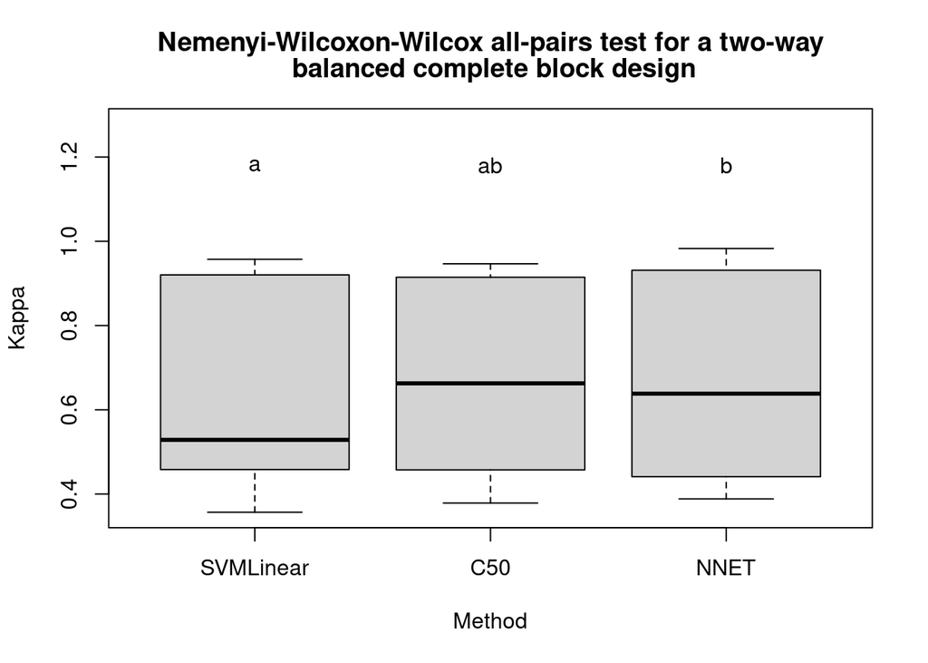

```r
plot(nemenyi.test)
```

# 5 Ejercicios

**Ejercicio 1:**

Se quiere comprobar si existen diferencias significativas en el comportamiento de dos clasificadores: SVM y una análisis lineal discriminante (LDA). Para tal fin, disponemos de los resultados de la precisión para cada uno de los pliegues para ambos clasificadores (fichero ejercicio1.dat). También se dispone de los objetos generados por la función `train()` correspondientes a los dos clasificadores (ficheros SVMFit y LDAFit) así como las base de datos sobre la que se ha hecho el experimento (el último atributo es la clase que es un factor, el primero es real y el resto enteros). Realizar las comprobaciones necesarias para llegar a una conclusión.

**Ejercicio 2:**

Se quiere comprobar si existen diferencias significativas en el comportamiento de cuatro regresores: RegA, RegB, RegC y RegD. Para tal fin, disponemos de los resultados del error cuadrático medio de cada regresor medido sobre nueve conjunto de datos (fichero ejercicio2.dat). Realizar las comprobaciones necesarias para llegar a una conclusión.

# Bibliografía

[1]

N. Japkowicz y M. Shah, *Evaluating learning algorithms: a classification perspective*. Cambridge University Press, 2011.